# Assignment-2

TarakRam Nunna

09/27/2021

```r
library(caret)
library(class)
library(ISLR)
library(dplyr)
```

```r
library(ggplot2)
library(fastDummies)
library(FNN)
```

Now I’ll load the UniversalBank.csv file which contains customer information and convert the categorical data to factors.

```r
BankData <- read.csv("UniversalBank.csv")
BankData$Personal.Loan<-factor(BankData$Personal.Loan,levels=c('0','1'),labels=c('No','Yes'))
summary(BankData)
```

```
##        ID            Age          Experience       Income          ZIP.Code
##  Min.   :   1   Min.   :23.00   Min.   :-3.0   Min.   :  8.00   Min.   : 9307
##  1st Qu.:1251   1st Qu.:35.00   1st Qu.:10.0   1st Qu.: 39.00   1st Qu.:91911
##  Median :2500   Median :45.00   Median :20.0   Median : 64.00   Median :93437
##  Mean   :2500   Mean   :45.34   Mean   :20.1   Mean   : 73.77   Mean   :93153
##  3rd Qu.:3750   3rd Qu.:55.00   3rd Qu.:30.0   3rd Qu.: 98.00   3rd Qu.:94608
##  Max.   :5000   Max.   :67.00   Max.   :43.0   Max.   :224.00   Max.   :96651
##      Family          CCAvg          Education        Mortgage     Personal.Loan
##  Min.   :1.000   Min.   : 0.000   Min.   :1.000   Min.   :  0.0   No :4520
##  1st Qu.:1.000   1st Qu.: 0.700   1st Qu.:1.000   1st Qu.:  0.0   Yes: 480
##  Median :2.000   Median : 1.500   Median :2.000   Median :  0.0
##  Mean   :2.396   Mean   : 1.938   Mean   :1.881   Mean   : 56.5
##  3rd Qu.:3.000   3rd Qu.: 2.500   3rd Qu.:3.000   3rd Qu.:101.0
##  Max.   :4.000   Max.   :10.000   Max.   :3.000   Max.   :635.0
##  Securities.Account   CD.Account         Online         CreditCard
##  Min.   :0.0000     Min.   :0.0000   Min.   :0.0000   Min.   :0.000
##  1st Qu.:0.0000     1st Qu.:0.0000   1st Qu.:0.0000   1st Qu.:0.000
##  Median :0.0000     Median :0.0000   Median :1.0000   Median :0.000
##  Mean   :0.1044     Mean   :0.0604   Mean   :0.5968   Mean   :0.294
##  3rd Qu.:0.0000     3rd Qu.:0.0000   3rd Qu.:1.0000   3rd Qu.:1.000
##  Max.   :1.0000     Max.   :1.0000   Max.   :1.0000   Max.   :1.000
```

## Data Selection

Now we should select our relevant data, (in this case, we will ID and Zip - we’ll also convert Education into 3 dummy variables for each education level) and divide the set into training (60%) and validation (40%) sets.

```r
dummy_bankdata <- dummy_columns(BankData, select_columns = 'Education')
m_bankdata <- select(dummy_bankdata,Age,Experience,Income,Family,CCAvg,Education_1,Education_2,Education_3,Mortgage,Personal.Loan,Securities.Account,CD.Account,Online,CreditCard)
m_bankdata <- m_bankdata %>% relocate(Personal.Loan,.after=last_col())#move personal.loan to the end to make our lives easier later on.
set.seed(1)
Train_Index <- sample(row.names(m_bankdata), .6*dim(m_bankdata)[1])
Val_Index <- setdiff(row.names(m_bankdata), Train_Index)
Train_Data <- m_bankdata[Train_Index,]
Validation_Data <- m_bankdata[Val_Index,]
summary(Train_Data)
```

```
##       Age          Experience        Income           Family
##  Min.   :23.00   Min.   :-3.00   Min.   :  8.00   Min.   :1.000
##  1st Qu.:36.00   1st Qu.:10.00   1st Qu.: 39.00   1st Qu.:1.000
##  Median :45.00   Median :20.00   Median : 63.00   Median :2.000
##  Mean   :45.43   Mean   :20.19   Mean   : 73.08   Mean   :2.388
##  3rd Qu.:55.00   3rd Qu.:30.00   3rd Qu.: 98.00   3rd Qu.:3.000
##  Max.   :67.00   Max.   :43.00   Max.   :224.00   Max.   :4.000
##      CCAvg         Education_1      Education_2     Education_3
##  Min.   : 0.000   Min.   :0.0000   Min.   :0.000   Min.   :0.0000
##  1st Qu.: 0.700   1st Qu.:0.0000   1st Qu.:0.000   1st Qu.:0.0000
##  Median : 1.500   Median :0.0000   Median :0.000   Median :0.0000
##  Mean   : 1.915   Mean   :0.4173   Mean   :0.285   Mean   :0.2977
##  3rd Qu.: 2.500   3rd Qu.:1.0000   3rd Qu.:1.000   3rd Qu.:1.0000
##  Max.   :10.000   Max.   :1.0000   Max.   :1.000   Max.   :1.0000
##     Mortgage      Securities.Account   CD.Account          Online
##  Min.   :  0.00   Min.   :0.0000     Min.   :0.00000   Min.   :0.0000
##  1st Qu.:  0.00   1st Qu.:0.0000     1st Qu.:0.00000   1st Qu.:0.0000
##  Median :  0.00   Median :0.0000     Median :0.00000   Median :1.0000
##  Mean   : 57.34   Mean   :0.1003     Mean   :0.05367   Mean   :0.5847
##  3rd Qu.:102.00   3rd Qu.:0.0000     3rd Qu.:0.00000   3rd Qu.:1.0000
##  Max.   :635.00   Max.   :1.0000     Max.   :1.00000   Max.   :1.0000
##    CreditCard     Personal.Loan
##  Min.   :0.0000   No :2725
##  1st Qu.:0.0000   Yes: 275
##  Median :0.0000
##  Mean   :0.2927
##  3rd Qu.:1.0000
##  Max.   :1.0000
```

## Now we’ll move to normalize the numeric data.

```r
columnsare <-c(1,2,3,4,5,9)
bankdata.norm.df <- m_bankdata
train.norm.df <- Train_Data
valid.norm.df <- Validation_Data
norm.values <- preProcess(Train_Data[,columnsare], method=c("center","scale"))
#put the normalized data back into the dataframes
train.norm.df[, columnsare] <-predict(norm.values,Train_Data[,columnsare])
valid.norm.df[, columnsare] <-predict(norm.values,Validation_Data[,columnsare])
summary(train.norm.df)
```

```
##       Age             Experience           Income            Family
##  Min.   :-1.97257   Min.   :-2.03718   Min.   :-1.4240   Min.   :-1.2058
##  1st Qu.:-0.82922   1st Qu.:-0.89531   1st Qu.:-0.7457   1st Qu.:-1.2058
##  Median :-0.03767   Median :-0.01695   Median :-0.2206   Median :-0.3368
##  Mean   : 0.00000   Mean   : 0.00000   Mean   : 0.0000   Mean   : 0.0000
##  3rd Qu.: 0.84183   3rd Qu.: 0.86141   3rd Qu.: 0.5452   3rd Qu.: 0.5321
##  Max.   : 1.89723   Max.   : 2.00328   Max.   : 3.3022   Max.   : 1.4010
##      CCAvg          Education_1      Education_2     Education_3
##  Min.   :-1.1059   Min.   :0.0000   Min.   :0.000   Min.   :0.0000
##  1st Qu.:-0.7016   1st Qu.:0.0000   1st Qu.:0.000   1st Qu.:0.0000
##  Median :-0.2396   Median :0.0000   Median :0.000   Median :0.0000
##  Mean   : 0.0000   Mean   :0.4173   Mean   :0.285   Mean   :0.2977
##  3rd Qu.: 0.3380   3rd Qu.:1.0000   3rd Qu.:1.000   3rd Qu.:1.0000
##  Max.   : 4.6700   Max.   :1.0000   Max.   :1.000   Max.   :1.0000
##     Mortgage       Securities.Account   CD.Account          Online
##  Min.   :-0.5679   Min.   :0.0000     Min.   :0.00000   Min.   :0.0000
##  1st Qu.:-0.5679   1st Qu.:0.0000     1st Qu.:0.00000   1st Qu.:0.0000
##  Median :-0.5679   Median :0.0000     Median :0.00000   Median :1.0000
##  Mean   : 0.0000   Mean   :0.1003     Mean   :0.05367   Mean   :0.5847
##  3rd Qu.: 0.4423   3rd Qu.:0.0000     3rd Qu.:0.00000   3rd Qu.:1.0000
##  Max.   : 5.7216   Max.   :1.0000     Max.   :1.00000   Max.   :1.0000
##    CreditCard     Personal.Loan
##  Min.   :0.0000   No :2725
##  1st Qu.:0.0000   Yes: 275
##  Median :0.0000
##  Mean   :0.2927
##  3rd Qu.:1.0000
##  Max.   :1.0000
```

## Building the K-NN model

```r
train.knn.predictors <- train.norm.df[, 1:13]
train.knn.success <-train.norm.df[,14]
valid.knn.predictors <- valid.norm.df[, 1:13]
valid.knn.success <-valid.norm.df[,14]
knn.results <- knn (train=train.knn.predictors, test=valid.knn.predictors, cl=train.knn.success, k=1, prob=TRUE)
confusionMatrix(knn.results,valid.knn.success, positive="Yes")
```

```
## Confusion Matrix and Statistics
##
##           Reference
## Prediction   No  Yes
##        No  1776   59
##        Yes   19  146
##
##                Accuracy : 0.961
##                  95% CI : (0.9516, 0.9691)
##     No Information Rate : 0.8975
##     P-Value [Acc > NIR] : < 2.2e-16
##
##                   Kappa : 0.768
##
##  Mcnemar's Test P-Value : 1.006e-05
##
##             Sensitivity : 0.7122
##             Specificity : 0.9894
##          Pos Pred Value : 0.8848
##          Neg Pred Value : 0.9678
##              Prevalence : 0.1025
##          Detection Rate : 0.0730
##    Detection Prevalence : 0.0825
##       Balanced Accuracy : 0.8508
##
##        'Positive' Class : Yes
##
```

##1. k=1 Now let’s take a sample customer with the following characteristics: Age = 40, Experience = 10, Income = 84, Family = 2, CCAvg = 2, Education_1 = 0, Education_2 = 1, Education_3 = 0, Mortgage = 0, Securities Account = 0, CD Account = 0, Online = 1, and Credit Card = 1.

We’ll evaluate him with our model.

```r
customertest = data.frame(Age = as.integer(40), Experience = as.integer(10), Income = as.integer(84), Family = as.integer(2), CCAvg = as.integer(2), Education1 = as.integer(0), Education2 = as.integer(1), Education3 = as.integer(0), Mortgage = as.integer(0), Securities.Account = as.integer(0), CD.Account = as.integer(0), Online = as.integer(1), CreditCard = as.integer(1)) #load the dataa into a customertest dataframe.
customer.norm.df <- customertest
customer.norm.df[, columnsare]<-predict(norm.values,customertest[,columnsare])#normalize the quantitative values
```

Now that we’ve imported and normalized the customer’s data, we will test him against our K-NN from earlier.

```r
set.seed(400)
customer.knn <- knn(train=train.knn.predictors, test=customer.norm.df,cl=train.knn.success,k=1, prob=TRUE) #calculate knn for customer.
head(customer.knn)
```

```
## [1] No
## Levels: No
```

We see that the model predicts this customer would not accept a loan offer.

## Tuning using Validation

#2. We will now test the performance of our model across various k’s on our validation set to find best k value.

```r
accuracy.df <- data.frame(k = seq(1,14,1), accuracy = rep(0 , 14))
#now we'll create a table of all k and accuracies from 1-14
for(i in 1:14){
  knn.pred <- knn(train.knn.predictors,valid.knn.predictors, cl=train.knn.success,k=i)
accuracy.df[i,2] <- confusionMatrix(knn.pred, valid.knn.success)$overall[1]
  }
accuracy.df
```

```
##     k accuracy
## 1   1   0.9610
## 2   2   0.9545
## 3   3   0.9620
## 4   4   0.9550
## 5   5   0.9580
## 6   6   0.9495
## 7   7   0.9545
## 8   8   0.9485
## 9   9   0.9540
## 10 10   0.9505
## 11 11   0.9520
## 12 12   0.9470
## 13 13   0.9510
## 14 14   0.9445
```

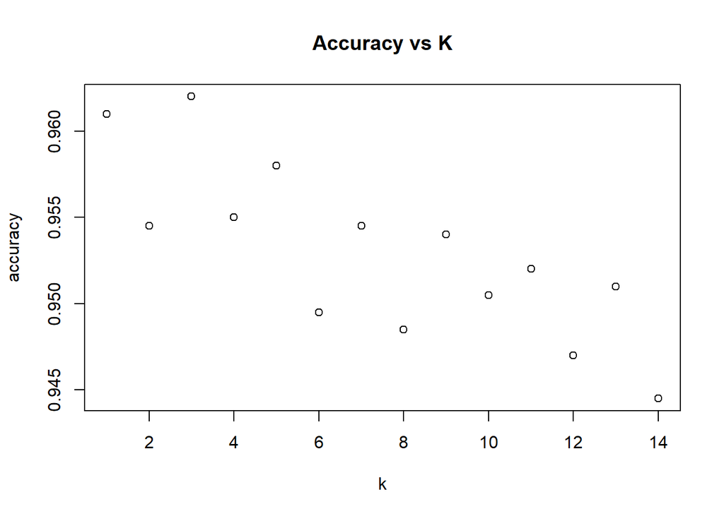

```r
plot(x=accuracy.df$k, y=accuracy.df$accuracy, main="Accuracy vs K", xlab="k",ylab="accuracy")
```

```r
which.max(accuracy.df$accuracy)
```

```
## [1] 3
```

We see from the ‘which’ function that the best performing k in the range of 1 to 14 is 3. This k is the most accurate for 3, and balances between overfitting and ignoring predictors.

```r
customer.knn3 <- knn(train=train.knn.predictors, test=customer.norm.df,cl=train.knn.success,k=3, prob=TRUE)
head(customer.knn3)
```

```
## [1] No
## Levels: No
```

## Further examination of k = 3

Below is a confusion matrix of the validation data for k=3 (the best k).

```r
knn.k3 <- knn(train = train.knn.predictors,test=valid.knn.predictors,cl=train.knn.success,k=3, prob=TRUE)
confusionMatrix(knn.k3,valid.knn.success,)
```

```
## Confusion Matrix and Statistics
##
##           Reference
## Prediction   No  Yes
##        No  1792   73
##        Yes    3  132
##
##                Accuracy : 0.962
##                  95% CI : (0.9527, 0.9699)
##     No Information Rate : 0.8975
##     P-Value [Acc > NIR] : < 2.2e-16
##
##                   Kappa : 0.7567
##
##  Mcnemar's Test P-Value : 2.476e-15
##
##             Sensitivity : 0.9983
##             Specificity : 0.6439
##          Pos Pred Value : 0.9609
##          Neg Pred Value : 0.9778
##              Prevalence : 0.8975
##          Detection Rate : 0.8960
##    Detection Prevalence : 0.9325
##       Balanced Accuracy : 0.8211
##
##        'Positive' Class : No
##
```

## Repartitioning for a test set

```r
set.seed(500)
Train_Index <- sample(row.names(m_bankdata), .5*dim(m_bankdata)[1])#create train index
Val_Index <- sample(setdiff(row.names(m_bankdata),Train_Index),.3*dim(m_bankdata)[1])#create validation index
Test_Index =setdiff(row.names(m_bankdata),union(Train_Index,Val_Index))#create test index
#load the data
Train_Data <- m_bankdata[Train_Index,]
Validation_Data <- m_bankdata[Val_Index,]
Test_Data <- m_bankdata [Test_Index,]
#normalize the quantitative data
norm.values3 <- preProcess(m_bankdata[,columnsare], method=c("center", "scale"))
train.norm.df3 = Train_Data
val.norm.df3 = Validation_Data
test.norm.df3 = Test_Data
train.norm.df3[, columnsare] <- predict(norm.values3, Train_Data[, columnsare])
val.norm.df3[, columnsare] <- predict(norm.values3, Validation_Data[, columnsare])
test.norm.df3[, columnsare] <- predict(norm.values3, Test_Data[, columnsare])
#run knn for all 3
knn.train <- knn(train=train.norm.df3[,-14],test=train.norm.df3[,-14],cl=train.norm.df3[,14], k=3, prob=TRUE)
knn.val<- knn(train=train.norm.df3[,-14],test=val.norm.df3[,-14],cl=train.norm.df3[,14],k=3, prob=TRUE)
knn.test<- knn(train=train.norm.df3[,-14],test=test.norm.df3[,-14],cl=train.norm.df3[,14],k=3, prob=TRUE)
#display the confusion matrices
confusionMatrix(knn.train,train.norm.df3[,14], positive="Yes")
```

```
## Confusion Matrix and Statistics
##
##           Reference
## Prediction   No  Yes
##        No  2274   50
##        Yes    2  174
##
##                Accuracy : 0.9792
##                  95% CI : (0.9728, 0.9844)
##     No Information Rate : 0.9104
##     P-Value [Acc > NIR] : < 2.2e-16
##
##                   Kappa : 0.8589
##
##  Mcnemar's Test P-Value : 7.138e-11
##
##             Sensitivity : 0.7768
##             Specificity : 0.9991
##          Pos Pred Value : 0.9886
##          Neg Pred Value : 0.9785
##              Prevalence : 0.0896
##          Detection Rate : 0.0696
##    Detection Prevalence : 0.0704
##       Balanced Accuracy : 0.8880
##
##        'Positive' Class : Yes
##
```

```r
confusionMatrix(knn.val,val.norm.df3[,14], positive="Yes")
```

```
## Confusion Matrix and Statistics
##
##           Reference
## Prediction   No  Yes
##        No  1335   65
##        Yes    5   95
##
##                Accuracy : 0.9533
##                  95% CI : (0.9414, 0.9634)
##     No Information Rate : 0.8933
##     P-Value [Acc > NIR] : < 2.2e-16
##
##                   Kappa : 0.7067
##
##  Mcnemar's Test P-Value : 1.766e-12
##
##             Sensitivity : 0.59375
##             Specificity : 0.99627
##          Pos Pred Value : 0.95000
##          Neg Pred Value : 0.95357
##              Prevalence : 0.10667
##          Detection Rate : 0.06333
##    Detection Prevalence : 0.06667
##       Balanced Accuracy : 0.79501
##
##        'Positive' Class : Yes
##
```

```r
confusionMatrix(knn.test,test.norm.df3[,14], positive="Yes")
```

```
## Confusion Matrix and Statistics
##
##           Reference
## Prediction  No Yes
##        No  904  42
##        Yes   0  54
##
##                Accuracy : 0.958
##                  95% CI : (0.9436, 0.9696)
##     No Information Rate : 0.904
##     P-Value [Acc > NIR] : 9.200e-11
##
##                   Kappa : 0.6992
##
##  Mcnemar's Test P-Value : 2.509e-10
##
##             Sensitivity : 0.5625
##             Specificity : 1.0000
##          Pos Pred Value : 1.0000
##          Neg Pred Value : 0.9556
##              Prevalence : 0.0960
##          Detection Rate : 0.0540
##    Detection Prevalence : 0.0540
##       Balanced Accuracy : 0.7812
##
##        'Positive' Class : Yes
##
```

From the confusion matrices the accuracies are Training: 97.92%; Validation: 95.33%; and Test: 95.8%. From this comparision we can understand that the accuracy of Training is more than Test and Validation. Hence we have best training model